# Report on Partisan Perceptual Bias

2023-03-14

I filtered all tweets with the keywords of “climate” and “warming.” I obtained 835 climate-pollen tweets, leading to 651 distinct cleaned tweets for further labeling. Here is a sample of some tweets.

```
## # A tibble: 10 × 2
##    user_screen_name text
##    <chr>            <chr>
##  1 leafwarbler      "RT @skmorgane: .@jessicablois: used network of fossil poll…
##  2 BlueCedarAngel   "RT @rabbleca: Affected by a longer #pollen season? You mig…
##  3 NeoCrp           "Flowers adjust UV pigments for climate change\n*As tempera…
##  4 _valerieanne     "RT @KTVU: Feeling like your allergies have been getting wo…
##  5 Pheqes           "Pollen in Vegas is surprisingly rough. I thought my allerg…
##  6 MconneX          "Pollen might play a much bigger role than we think in clou…
##  7 TerryWBZ         "@SBarnacoat Not really, fairly typical season thus far...c…
##  8 CLMTFortWorth    "RT @C2ES_org: . @EPA report: Changes in permafrost causing…
##  9 slapknoot        "When it starts warming up and the pollen comes out of hidi…
## 10 NESTA_US         "#cCimatechange affecting #Allergies increasing those affec…
```

I manually labeled all distinct climate-pollen tweets to select for those related to climate change driving earlier, longer, and more intense pollen seasons. I then distinguished the tweets that showed belief or disbelief of this effect, and if the tweets are based on expert opinions (scientific report, news, communication with scientists) or are personal opinions.

Here I show some samples of belief and disbelief in the climate change effect.

[output not shown]

Here I show some samples of tweets based on expert opinions and personal opinions.

```
## # A tibble: 10 × 2
## # Groups:   science [2]
##    text                                                                  science
##    <chr>                                                                 <chr>
##  1 "'Pollen Tsunami' is real and it's awful http://t.co/7McBYslcMF #usw… person…
##  2 "Pollen count going up because of global warming. RIP my nose."       person…
##  3 "RT @theurbancore: If global warming is responsible for this pollen … person…
##  4 "@Claire13323 @RCdeWinter @angelakaplan7 @trapdinawrpool @Seekerotru… person…
##  5 "@Vincentsmith323 It is another result of global warming. Longer pol… person…
##  6 "Climate change is lengthening the allergy season.\n\nLocal temperat… expert
##  7 "‼️ INFORMATION ‼️\n\nWhy is pollen season lasting longer?\n\nAs the c… expert
##  8 "RT @ACAAI: World Allergy Week is April 4-10. The focus is how clima… expert
##  9 "RT @pauldavidpope: Climate Change Is Making Your Allergies Even Wor… expert
## 10 "#business July 1 News: Allergies Getting Worse? Climate Change Coul… expert
```

I scored the political ideology of all 790 users posting climate-pollen tweets using the package *tweetscores*. The scores were calculated based on the influential (political) account an user is following. Many users cannot be scored as they did not authorize data retrieval, deleted their accounts, or did not follow influential accounts.

As a contrast, I also randomly selected 1000 pollen tweets, obtained a list of unique users, and scored their political ideology.

# General belief

**Research question 1**: Is there a partisan bias on how likely people are to believe in the climate change impacts on pollen season?

Here is a comparison of the distributions of political ideology scores in the wide user group discussing pollen (blue) and among the smaller user group (356 users) (red) that stated belief in climate change impacts.

The differences between the two distributions was not statistically significant (Kolmogorov-Smirnov test, *p* > 0.05), although the general comparison of the proportion of left vs. right individuals was consistent with our hypothesis.

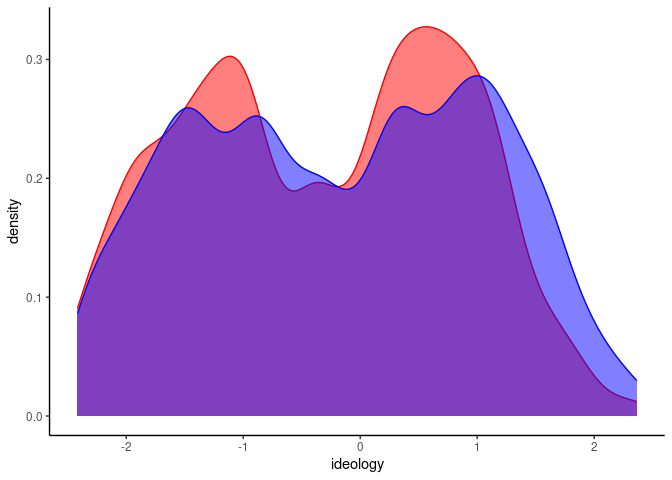

| ideology | climate-pollen group | pollen group |
| --- | --- | --- |
| left | 0.5421348 | 0.5240275 |
| right | 0.4578652 | 0.4759725 |

```
##
##  Asymptotic two-sample Kolmogorov-Smirnov test
##
## data:  df_CC_ideo_sel$ideology and df_rand_ideo_sel$ideology
## D = 0.085587, p-value = 0.1129
## alternative hypothesis: two-sided
```

**Message 1.1**: There did not seem to be a significant partisan bias on the belief in climate change effects on pollen season. Both left- and right-leaning users that have attention on pollen have a similar probability of supporting this belief. This is an encouraging message for climate change education, as pollen phenology might provide a powerful message can raise climate change awareness in both parties.

I further compared the distributions of political ideology scores in the wide user group discussing pollen (blue) and among the smaller user group (7 users) (red) that expressed disbelief in climate change impacts. There were very few tweets (<10) that expressed disbelief and they are almost all from right-leaning individuals.

The differences between the two distributions was statistically significant (*p* <= 0.05), although the general comparison of the proportion of left vs. right individuals was consistent with our hypothesis.

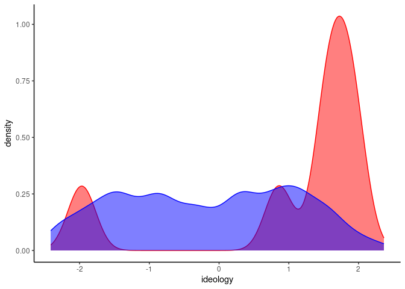

| ideology | climate-pollen group | pollen group |
| --- | --- | --- |
| left | 0.1428571 | 0.5240275 |
| right | 0.8571429 | 0.4759725 |

```
##
##  Exact two-sample Kolmogorov-Smirnov test
##
## data:  df_CC_ideo_sel$ideology and df_rand_ideo_sel$ideology
## D = 0.62504, p-value = 0.003956
## alternative hypothesis: two-sided
```

**Message 1.2**: The message of climate change impacts on pollen season receives some skepticism, mostly by right-leaning users, although the proportion of disbelief is small compared to the popular opinion.

# Knowledge production

**Research question 2**: Is there a partisan bias on how people communicate this belief personally, without an immediate influence of media?

**Hypothesis 2**: A left-leaning user is more likely to *personally comment on* climate change impacts on pollen season compared to a right-leaning user, if they both talk about pollen. Specifically, the statistical distributions of political ideology scores differ between those who discuss pollen and those who also expressed belief in climate change impacts *based on personal opinion*.

There were 27 users expressed belief on climate change impacts on pollen seasons based on personal opinion (red). The partisan bias on personal opinion was marginally significant (*p* = 0.057), being a lot stronger than the non-significant bias on belief based on expert opinion and personal opinion taken together.

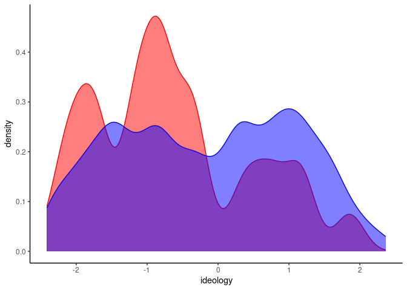

| ideology | climate-pollen group | pollen group |
| --- | --- | --- |
| left | 0.7407407 | 0.5240275 |
| right | 0.2592593 | 0.4759725 |

```
##
##  Asymptotic two-sample Kolmogorov-Smirnov test
##
## data:  df_CC_ideo_sel$ideology and df_rand_ideo_sel$ideology
## D = 0.26477, p-value = 0.05658
## alternative hypothesis: two-sided
```

In contrast, when only looking at belief expressed based on expert opinion (330 users) (red), the partisan bias was again non-significant.

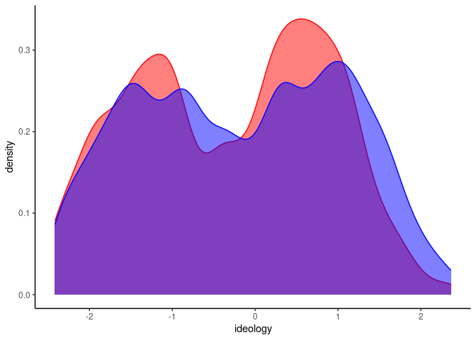

| ideology | climate-pollen group | pollen group |
| --- | --- | --- |
| left | 0.5272727 | 0.5240275 |
| right | 0.4727273 | 0.4759725 |

```
##
##  Asymptotic two-sample Kolmogorov-Smirnov test
##
## data:  df_CC_ideo_sel$ideology and df_rand_ideo_sel$ideology
## D = 0.086034, p-value = 0.1236
## alternative hypothesis: two-sided
```

**Message 2**: The lack of overall partisan bias shown in Question 1 may be attributed to a top-down approach, i.e., large exposure to expert opinions, communicated through scientific articles, news reports, and experts’ personal communication. On the other hand, the knowledge distribution via the bottom-up approach, i.e., personal opinion by non-experts, is still likely to have a partisan bias. Although the message of climate change impacts on pollen season may reach right-leaning users well, the message may be less likely to be amplified through personal communications in right-leaning communities.

# Knowledge distribution

**Research question 3**: Is there a partisan bias in the distribution of this belief in the social network?

**Hypothesis 3**: A user is more likely to receive and distribute information on climate change impacts on pollen season from a user or similar ideology. Specifically, the ideology of the target user (user who expressed belief) has a statistically significant correlation with the ideology of the source (mentioned, retweeted, or replied user).

As a preliminary analysis, I explored a network around influential nodes in the network communicating climate change impacts on pollen season.

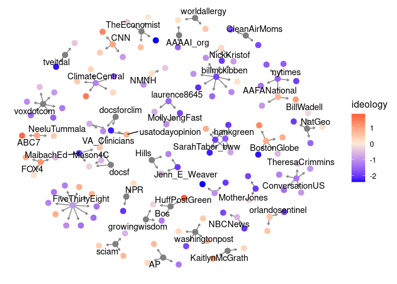

Based on 151 pairs of source and target, found a statistically significant positive correlation (Spearman, *p* <= 0.05) between the ideology of source and targets.

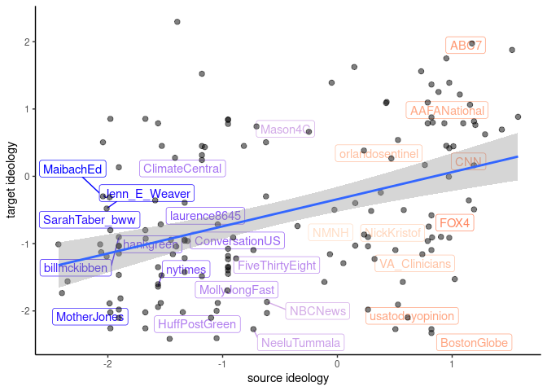

```
##
##  Pearson's product-moment correlation
##
## data:  df_CC_net_ideo$from_ideo and df_CC_net_ideo$to_ideo
## t = 5.3176, df = 149, p-value = 3.775e-07
## alternative hypothesis: true correlation is not equal to 0
## 95 percent confidence interval:
##  0.2559879 0.5255857
## sample estimates:
##       cor
## 0.3993861
```

```
##
##  Spearman's rank correlation rho
##
## data:  df_CC_net_ideo$from_ideo and df_CC_net_ideo$to_ideo
## S = 349557, p-value = 7.009e-07
## alternative hypothesis: true rho is not equal to 0
## sample estimates:
##       rho
## 0.3908038
```

**Message 3**: Although both left- and right-leaning users have generally similar belief in the climate change impacts on pollen season, possibly attributed to the exposure to expert opinion, the partisan bias is still very strong in terms of the source of information. People are more likely to receive information from sources with a similar political ideology. This result is consistent with the information theory in social psychology, suggesting that individuals choose to interact with others who hold similar beliefs (homophily). It is encouraging that this knowledge of climate change impacts on pollen season reach diverse audience, but there may still be information silo in the communication of this knowledge across partisans.